# Seeds of Success - Diversity and impact of collections conserved in the USDA National Plant Germplasm System

Daniel Carver, Colin Khoury, Stephanie Greene, (potentially additional authors from Pullman, BLM)

June 22, 2018

DRAFT - this is a working document - at this stage the majority of the effort of the authors has been placed into developing a series of graphic/tables that summarizes the relationship between the SOS and ARS. - The text within the document is priliminary and is expected to undergo major revisions based in part on input from outside contributors, as such much of the writen content is mearly an outline of what is to be expected.

# Abstract

Summarize the relationship between the BLM Seeds Of Success (SOS) program and the USDA ARS division. These two organizations are leading the nation in collecting, conserving, and preserving the native plants present on public lands.

# 1 Introduction

The Seeds of Success program was established in 2001 to facilitate the collection of native seeds. To make use of the seeds collected, the SOS program partners with land management agencies to support the re-vegetation of areas, academic and professional partners to promote and advance scientific research, and the United States Department of Agriculture for the long term preservation of species genetic diversity.

- fill this out to capture aims
- continue to add content to this as I learn more; ask Colin, Stephanie, and others to add to this background

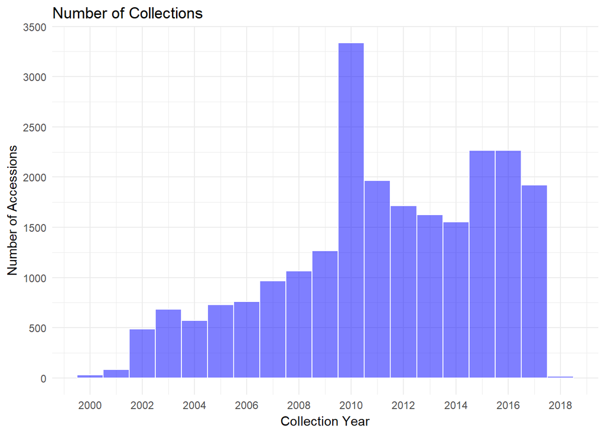

SOS accessions have information about the species collected, the region it was collected from, the land management agency where that collection occurred, and positional data in the form of latitude, longitude, and elevation. This data provides information about the seeds collected but does not tell us anything about what happened to the seeds after the collection occurs. The article is meant to create those connections and tell the full story of how these seeds are providing services to the landscape and understanding of the species. This will be done by accessing how many of these collections represent economically useful and/or crop wild relatives at both the national and international scale. The relationship between the SOS collections and the ARS collections will be examined to determine how many collections are in long term storage and who is using the seeds outside of the ARS and for what purpose. Understanding these relationship will highlight the successes, challenges, and future means of development between the SOS and ARS programs

- this can be added to. It’s the first time we talk about CWR and there need more of an introductions Specific the two datasets used
- background on both the organizations needs to be added based on the final audience

# 2 Methods

- data acquisition
  - SOS BLM: Information regarding the SOS collection was provide as a csv file by the Seeds of Success Program National Collection Curator in June of 2018. This dataset is updated as more field collecting occurs. All data from the years 2017 and earlier is assumed to be correct and complete. The data collected by the SOS program contains a rich set of specific information regarding the plant from which seed is collected as well as the geography region and ecosystem that the plant was found with. **Is the blm data a public dataset? How can people access this data**
  - GRIN GLOBAL : The USDA’s National Plant Germplasm System has utilized the Germplasm Resource Information Network(GRIN) to provide public access to informing regarding the accession maintained by the USDA. The data is public available through the desktop software program, [GRIN-Global](https://www.grin-global.org/). This data can also be accessed through a web site hosted by Crop Trust, Biodiversity International, and the USDA that allows for the querying of the GRIN-global database. The website can be found [here](https://npgsweb.ars-grin.gov/gringlobal/taxon/taxonomysearch.aspx) All datasets containing information from on the USDA accession were retrieved from the GRIN global databased and stored as csvs.
  - Pullman office: Before assessing the datasets a meeting of individuals involved with the management of the SOS accession was held to identify the primary questions, define the process of transferring the collections between the agencies, and understand the processing and management of the collections once they enter the USDA long term storage system. **should we reference some of the individuals from pullman here**
- data processing
  - rmarkdown : The datasets were processed, joined, and query using the statistically programming language R. Specific libraries that were use include: plyr, tidyr, dplyr, and ggplot2. The report is compiled as an RMarkdown document to help with the reproducibility of the content as the relationship between the two organizations continues to develop. **will this stay an in house document or will it be make public.**

# 3 Results

The results are split into sections based on the primary questions we attempted to answer. We should probably highlight the questions earily in the document but for now ther are listed here. 1. How diverse is the SOS collection 2. How many of the SOS accessions are considered CWR, WUS, or WEP 3. How many of the SOS accessions are mainted on ARS systes (GRIN and backed up at NLGRP) how does this effect the diversity and usefullness of the collection. 4. Within the ARS which locations are resposible for the SOS accessions 5. How successful is the ARS in germinating the seeds provides by the SOS program 6. Who is using the SOS accessions and what for

## 3.1 Diversity

|  | All Accessions | Total Number of Families | Total Number of Genera | Total Number of Taxa |
| --- | --- | --- | --- | --- |
| 1 | 23577 | 176 | 1153 | 5651 |

This Seeds of Success program has collected a total of 23577 seed samples. Of which 176 plant families 1153 plant genus and 2693 unique sub species are represented.

- this are interesting numbers but some knowledge on how they relate to the total number of species present in the country might make the factoids stand out some more

An accession is a collection of seeds from a single sampling location. There are enough seeds in each accession to split the collection for short term storage, long term preservation, and distribution. Out of the 176 families collected half of the total accessions collected come from just 5 families. The commonality and number of species represented by the top 5 collected families may explain this observed relationship.

| Family | Total Number of Accessions |
| --- | --- |
| ASTERACEAE | 5303 |
| POACEAE | 4522 |
| CYPERACEAE | 1165 |
| FABACEAE | 1122 |
| SCROPHULARIACEAE | 1027 |
| ROSACEAE | 977 |
| CHENOPODIACEAE | 614 |
| APIACEAE | 585 |
| POLYGONACEAE | 582 |
| ONAGRACEAE | 434 |

[output cut: 166 more lines]

## 3.2 Crop wild relatives and other economic plants

The importance of this collection is increased by the fact that many of the seed taxa that were collected by the SOS program are defined as either Crop Wild Relatives or World Economic Plants. Crop Wild Relatives (CWR) are the genetic predecessors of modern crops and are found throughout the diverse ecological and bio physiological environments of the world. The variability in growing conditions and potential geographic isolation between stands has shown that CWRs contain a higher level of genetic diversity (*reference this*) . The subsequent traits found within CWR are used to add to the resistance, quality, and breeding efficiency of modern crops (*reference this*).

- add a bit about the various economic use categories define by GRIN
- talk about the WEP data set; how it was developed and why we are using it *get reference for the WEP dataset received from Daniel*.
- expand upon the k13 data source a bit to explain why we are using it.
- add genus by accession - CWR WUS WEP top 20 or 50 chart/table

This study is using dataset complied by Khoury et al 2013 and Wiersema and Leon 20?? to identify species that are considered CWR, WUS, or WEP. These dataset will be joined to the SOS dataset based on taxa name to identify how many of the SOS accession are considered CWR, WUS, and or WEP. The chart below is defining the primary acronyms that are used in the remainder of this document

| Acronym | Meaning |
| --- | --- |
| SOS | Seeds of Success |
| GRIN | Germplasm Resource Information Network |
| NLGRP | National Laboratory Genetic Resource Presevation |
| WUS | Wild Utilize Species |
| K13 | Khoury et al 2013 |
| CWR | Crop Wild Relative |
| WEP | World Economic Plants |

The table below illustrates the diversity of genus and taxa represented with the various datasets. The SOS and K13 data sets reference plants found in **North America or US** the World Economic Plants is a world wide data set and hence has significantly more diversity. In the case of preservation it is important to understand the total diversity represented as well as the sample size of that diversity.

|  | Total Number of Genus | Total Number of Species |
| --- | --- | --- |
| SOS | 1153 | 2693 |
| WUS in K13 | 833 | 2101 |
| CWR in K13 | 160 | 2488 |
| WEP | 3354 | 15768 |

We can test that by observing what proportion of the accessions collected by SOS are classified are a Wild Utilized Species, Crop Wild Relative, or a World Economic Plant. The chart below shows the number of species that are found within the K13 and WEP databased and were collected by the SOS program as well as the proportion of the total SOS accessions. The high number of taxa collected and the low proportion of the accession imply that the SOS program is collection many of the WUS, CWR, and WEP species in low number of accessions.

| label | SOS Collection |
| --- | --- |
| Total Accessions | 23577.00 |
| Total Number Taxa | 5651.00 |
| Taxa that are WUS per K13 | 985.00 |
| Percent of SOS Accessions that are WUS per K13 | 4.18 |
| Genus that are WUS per K13 | 465.00 |
| Taxa that are CWR per K13 | 700.00 |
| Percent of SOS Accessions that are CWR per K13 | 2.97 |
| Genus that are CWR per K13 | 94.00 |
| Taxa that are WEP | 1106.00 |
| Percentage of SOS Accessions that are WEP | 4.69 |

[output cut: 1 more lines]

## 3.3 Conservation

The Seeds of Success program provides the boots on the ground effort in the collection of seed resources. The program partners with the Agricultural Research Service of the USDA to store, maintain, and distribute the seeds collected. The Pullman, Washington section of the ARS is the group responsible for the initial on boarding and entering of the seeds into the Genetic Resource Inventory Network (GRIN) as well as maintaining the seeds in environments that support preservation. Just as was shown above the table below shows the relationship between the SOS accession that have made it into the GRIN global database and the WUS,CWR, and WEP species. Not all SOS accession make it into the ARS and GRIN systems as a result the total taxa and percent of SOS accession that are representative of a useful plant.

### 3.3.1 stored within ARS system

| label | SOS Collection | SOS in GRIN Global |
| --- | --- | --- |
| Total Accessions | 23577.00 | 14767.00 |
| Total Number Taxa | 5651.00 | 4088.00 |
| Taxa that are WUS per K13 | 985.00 | 808.00 |
| Percent of SOS Accessions that are WUS per K13 | 4.18 | 3.43 |
| Genus that are WUS per K13 | 465.00 | 397.00 |
| Taxa that are CWR per K13 | 700.00 | 586.00 |
| Percent of SOS Accessions that are CWR per K13 | 2.97 | 2.49 |
| Genus that are CWR per K13 | 94.00 | 85.00 |
| Taxa that are WEP | 1106.00 | 931.00 |
| Percentage of SOS Accessions that are WEP | 4.69 | 3.95 |

[output cut: 1 more lines]

The difference in the total number of accessions collected by SOS and the number of accessions recorded in GRIN is significant. Part of this can be explained by a potential backlog of samples within the ARS and a lag in delivery time between collection and distribution. It generally takes a year from when the seeds are collect to when they are received by the ARS.

For example, a total of 21389 accessions were brought into the SOS collection before 2017. The ARS is still processing SOS data from 2017. Therefore, 69.04 percent of the samples collected by SOS have been brought into the ARS and GRIN Global system.

### 3.3.2 How much is at NLGRP for long term backup

Once within the ARS system the quality of the seed collections are accessed and samples that are deemed beneficial to preserve over an extended period of time are transfer to the National Laboratory for Genetic Resource Preservation in Fort Collins, Colorado. The NLRGP specializes in the long term storage of genetic resources. If a set of seeds is stored at NLGRP it can be assured that it is protect and preserved to the highest standard. The coordinating efforts to bring seeds into the long term storage is essential to the longevity of the genetic material store within the seeds.

| label | SOS Collection | SOS in GRIN Global | SOS in NLGRP |
| --- | --- | --- | --- |
| Total Accessions | 23577.00 | 14767.00 | 11795.00 |
| Total Number Taxa | 5651.00 | 4088.00 | 3509.00 |
| Taxa that are WUS per K13 | 985.00 | 808.00 | 732.00 |
| Percent of SOS Accessions that are WUS per K13 | 4.18 | 3.43 | 3.10 |
| Genus that are WUS per K13 | 465.00 | 397.00 | 365.00 |
| Taxa that are CWR per K13 | 700.00 | 586.00 | 510.00 |
| Percent of SOS Accessions that are CWR per K13 | 2.97 | 2.49 | 2.16 |
| Genus that are CWR per K13 | 94.00 | 85.00 | 79.00 |
| Taxa that are WEP | 1106.00 | 931.00 | 801.00 |
| Percentage of SOS Accessions that are WEP | 4.69 | 3.95 | 3.40 |

[output cut: 1 more lines]

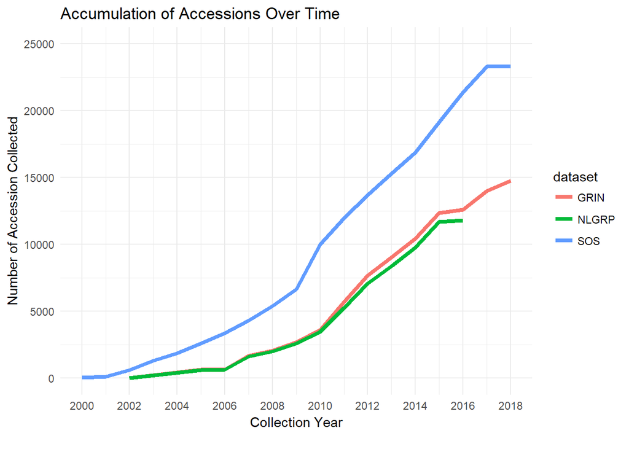

## 3.4 Where are Accession Maintained

The challenge of coordinating the preservation of these seeds is seen in part by how my samples become orphaned within the system. Orphaned seeds are those which do not fit into any of the existing collections. As a results seed curators need to assess how the seeds can best be integrated and is it worth incorporating that sample. While this decision making process is occurring the seeds are not being backed up and are not grown out to plants to replenish the existing seed population.

```r
# call in sosAccessions: summaries by maintaince site or owned by ***check with Colin or Renee on this one***
# produce a table showing number of successions and proportion of total


#group by location and derive number of taxon
sosAccTaxa <- grinData %>%
  group_by(Accession.Prefix) %>%
  dplyr::summarise(uniqueNumber = n_distinct(Taxon)) %>%
  dplyr::rename(Facility = "Accession.Prefix", UniqueTaxa = "uniqueNumber" )

library(plyr)
# subet columns needed.
sosOwner <- count(grinData$Accession.Prefix)%>%
  arrange(desc(freq))%>%
  dplyr::rename(Facility = x, NumberOfAccessions = freq)%>%
  mutate(FacilityName = c("Western Regional Plant Introduction Station, Washington", "Ornamental Plant Germplasm Center, Ohio", "National Animal Disease Center, Iowa",
                          "Plant Introduction Research, Iowa", "NSL unknown" , "Plant Genetic Resources Conservation Unit, Georgia", "SARU unknown Plants from alaska??", "Missing Data"))

#join the two datasets
sosOwner2 <- left_join(sosOwner, sosAccTaxa, by='Facility', type='left', match='all') %>%
  dplyr::rename(FacilityAcronym = "Facility") %>%
  select(FacilityName, FacilityAcronym, NumberOfAccessions, UniqueTaxa)

sosOwner2
```

| FacilityName | FacilityAcronym | NumberOfAccessions | UniqueTaxa |
| --- | --- | --- | --- |
| Western Regional Plant Introduction Station, Washington | W6 | 11958 | 3257 |
| Ornamental Plant Germplasm Center, Ohio | OPGC | 1179 | 549 |
| National Animal Disease Center, Iowa | Ames | 766 | 269 |
| Plant Introduction Research, Iowa | PI | 404 | 181 |
| NSL unknown | NSL | 252 | 237 |
| Plant Genetic Resources Conservation Unit, Georgia | Grif | 196 | 65 |
| SARU unknown Plants from alaska?? | SARU | 7 | 6 |
| Missing Data | NA | 5 | 4 |

The majority of the SOS collection is maintained by the ARS in Pullman, Washington (W6). This is where the native plant collection is based. Accession that are maintained at other locations are there due to the request of other curators. The are accession that are very unlikely to be orphaned. It is different to determine from data alone how many of the accession at W6 an being actively store but not regenerated.

## 3.5 Viability of SOS seeds

Collection and storage are only part of the story. Germination and the ability to grow out the plant to collect new seeds is a large part of what the ARS supports. The troublesome fact about the SOS seeds is that these species have not often been collected and maintained in seed banks before the initiation of the SOS program. Often little is known about the conditions required to germinate the seeds.

```r
colnames(viability) <- c('Genus', 'percentViable' )
arrange(viability, desc(percentViable))
```

| Genus | percentViable |
| --- | --- |
| Cosmos | 100.00000 |
| Moehringia | 100.00000 |
| Robinia | 100.00000 |
| Zephyranthes | 100.00000 |
| Phaseolus | 99.50000 |
| Convolvulus | 99.00000 |
| Alopecurus | 98.00000 |
| Houstonia | 98.00000 |
| Phryma | 98.00000 |
| Selenia | 98.00000 |

[output cut: 784 more lines]

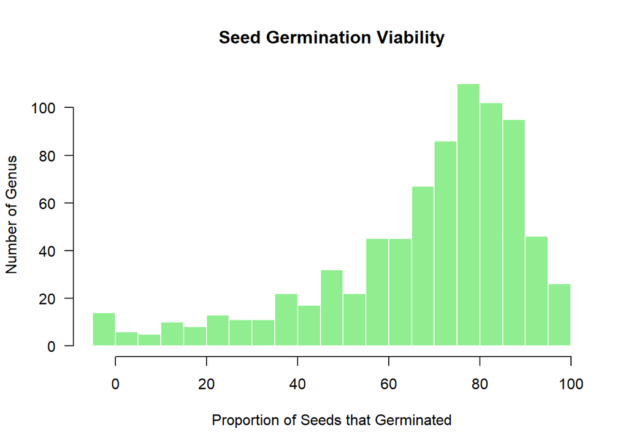

This distribution shows that the majority of the species collected by the SOS can be germinated given the current level of understanding. Species that had a very low germination success rate will require more research to understand what are the necessary conditions to promote successful germination. Until those methods are understood it may not be possible to maintain the population.

## 3.6 Distribution of SOS Materials

The ARS systems stores and distributes the seeds that are collected by SOS. Seeds are distributed for a number of reasons including academic research studies and educational demonstrations. Many of the distributions take place within the ARS when seeds are sent to and from various seed labs. The distribution of seeds is end user driven and a result the volume of seeds transferred fluctuates over time.

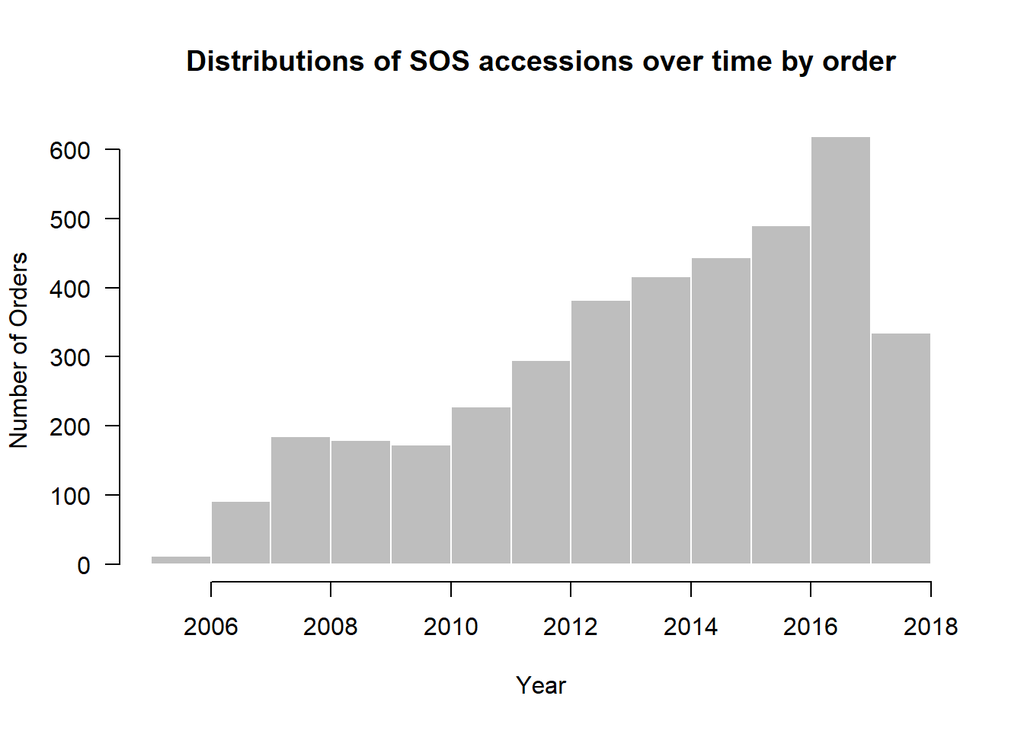

The seeds can be used for multiple reasons but by far Research and Education are the top two requests. The first bin on this graph is 2005 and the last is 2017.

| Reason for Distribution | Individual Shipments |
| --- | --- |
|  | 2658 |
| Research | 808 |
| Education | 408 |
| Other | 103 |
| Home Gardening | 41 |
| Gao, Bo, USDA-ARS, WRPIS | 31 |
| Cruver, Jacqueline, Washington State University | 3 |
| Before sending seeds, please contact me for documents validation | 1 |
| Bo inputted it from PCIT. | 1 |
| Brad replied, Approve. Melanie replied, Okay to send my part. | 1 |

[output cut: 12 more lines]

These values are written in by individuals who place the order so while this shows trends there are many unique options that do not fall into a group because of the extra text.

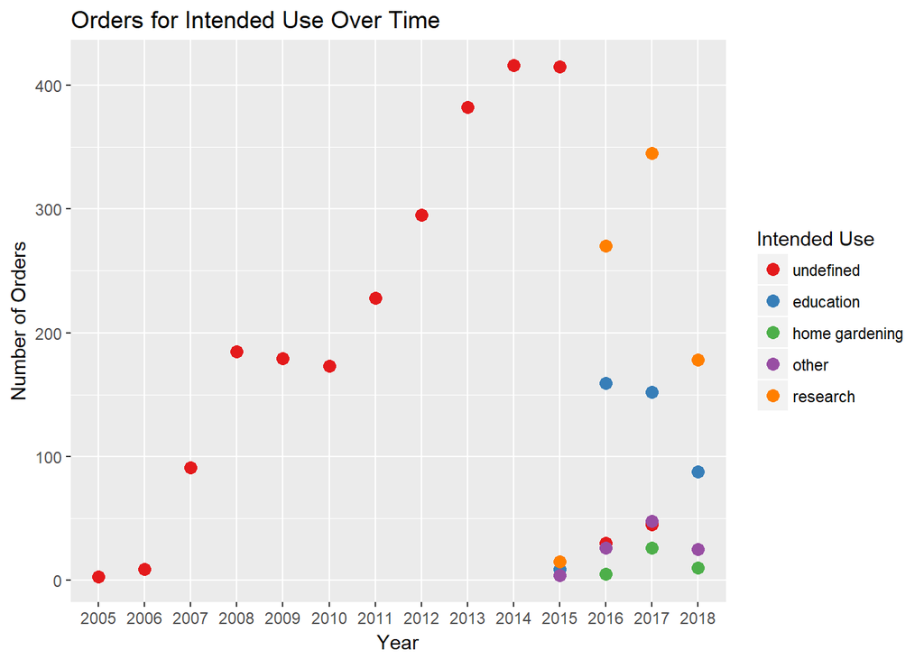

If we take a look at the deliveries over time we can see there is some distinct variability over time. The undefined variable is present because before 2015 the reason for distribution was not recorded.

Table illustrating the total number of seeds sent per genus. There has been a total of 18078 seeds distributed by the ARS that were collected by the SOS program. *At the same time I’m a little wary of this data count. why would someone order a single seed. 2/3 of all order are under 10 seeds. Does that make sense* This will be a good question for the other individuals more familiar with the delivery process.

| EntityRecievingSeeds | NumberOfGenusDistributed | SamplesDistributed |
| --- | --- | --- |
| U.S. state agencies and all universities | 514 | 4966 |
| U.S. individual no affiliation | 476 | 6384 |
| Foreign non-commercial organization | 297 | 2180 |
| U.S. commercial company | 288 | 1647 |
| U.S. non-profit organizations | 261 | 1360 |
| Foreign commercial company | 99 | 847 |
| U.S. federal agency (not AID or ARS) | 87 | 501 |
| Foreign individual no affiliation | 48 | 125 |
| Foreign genebank/genetic resources unit | 33 | 68 |

There are a total of 18078 seeds that have been distributed by the ARS. Of that 16802, are considered to be either Wild Utilized Plants or Crop Wild Relatives. This is representing 465 unique genus

This chart shows the number of times an order was place for a specific accession.

| Accession | Accessions Pulled From |
| --- | --- |
| NA | 1793 |
| W6 27227 | 32 |
| Ames 29888 | 27 |
| W6 26755 | 26 |
| W6 45791 | 23 |
| PI 675069 | 21 |
| W6 30326 | 21 |
| W6 32535 | 21 |
| W6 32664 | 21 |
| W6 26980 | 19 |

[output cut: 4141 more lines]

This chart shows the number of times a specific taxa was has been delivered. These deliveries could come from multiple accessions.

| Taxon | Total Delivered | Total Packets?? |
| --- | --- | --- |
| NA | 1627 | 311 |
| Achnatherum hymenoides | 246 | 299 |
| Salvia columbariae | 152 | 310 |
| Achillea millefolium | 105 | 304 |
| Poa secunda | 88 | 299 |
| Koeleria macrantha | 83 | 285 |
| Asclepias speciosa | 71 | 298 |
| Linum lewisii | 71 | 260 |
| Elymus elymoides | 70 | 268 |
| Poa fendleriana | 69 | 244 |

[output cut: 1875 more lines]

This graphic shows which location is receiving the greatest diversity of taxon

| Taxon | Total Taxon | Total Delivered | Total Packets?? |
| --- | --- | --- | --- |
| Young, Carolyn, Noble Research Institute, 2510 Sam Noble Parkway, Ardmore, Oklahoma, United States | 17 | 196 | 220 |
| Roybal, Carla, Northern Arizona University, Biology Department, 617 S Beaver St, Flagstaff, Arizona, United States | 15 | 162 | 69 |
| Van Herwijnen, Zeger, Rijk Zwaan Breeding, burg crezeelaan 40, De Lier, South Holland, Netherlands | 65 | 142 | 307 |
| Cramer, Chris, New Mexico State Univ., N127 Skeen Hall, Las Cruces, New Mexico, United States | 80 | 138 | 258 |
| Ford, Tim, IPPFBE, Inc., 400 North 1000 East, Hyde Park, Utah, United States | 5 | 127 | 280 |
| Rodriguez, Jessica, , 15595 Tetley Street, Hacienda Heights, California, United States | 124 | 126 | 299 |
| Arnow, Jonathan, Alpine Distributors, 57 Home Fair Drive, Farfield, Connecticut, United States | 88 | 114 | 299 |
| Rhode, David, Desert Research Institute, 2215 Raggio Parkway, Reno, Nevada, United States | 111 | 112 | 209 |
| Kolano, Bozena, University of Silesia, Department of Plant Anatomy and Cytology, Silesia, Katowice, Poland | 26 | 101 | 299 |
| Tucker, Arthur O., Delaware State University, Department of Agriculture & Natural Resources, Dover, Delaware, United States | 84 | 85 | 188 |

[output cut: 2329 more lines]

# 4 to Do

- Investigate reasons for use- narrative description in GRIN Global
- feedback on existing process

# 5 Discussion

- there is a lot of room for narrative and exploration of these results. Collaboration with individuals more involved in the processing of these accession need to be pulled in to provide opinions and highlight significance of results per each section